# PML Course Project

Bobby Kimble

September 23, 2017

# Introduction:

## Background

Using devices such as Jawbone Up, Nike FuelBand, and Fitbit it is now possible to collect a large amount of data about personal activity relatively inexpensively. These type of devices are part of the quantified self movement – a group of enthusiasts who take measurements about themselves regularly to improve their health, to find patterns in their behavior, or because they are tech geeks. One thing that people regularly do is quantify how much of a particular activity they do, but they rarely quantify how well they do it. In this project, your goal will be to use data from accelerometers on the belt, forearm, arm, and dumbell of 6 participants. They were asked to perform barbell lifts correctly and incorrectly in 5 different ways. More information is available from the website here: http://groupware.les.inf.puc-rio.br/har (see the section on the Weight Lifting Exercise Dataset). Data

The training data for this project are available here:

https://d396qusza40orc.cloudfront.net/predmachlearn/pml-training.csv

The test data are available here:

https://d396qusza40orc.cloudfront.net/predmachlearn/pml-testing.csv

The data for this project come from this source: http://groupware.les.inf.puc-rio.br/har. If you use the document you create for this class for any purpose please cite them as they have been very generous in allowing their data to be used for this kind of assignment.

## Goal

The goal of your project is to predict the manner in which they did the exercise. This is the “classe” variable in the training set. You may use any of the other variables to predict with. You should create a report describing how you built your model, how you used cross validation, what you think the expected out of sample error is, and why you made the choices you did. You will also use your prediction model to predict 20 different test cases.

## Load libraries

```r
library(caret)
```

```r
library(rpart)
library(rpart.plot)
library(randomForest)
library(knitr)
```

## Load the data and remove NA values

```r
set.seed(34343)

trainUrl <- "http://d396qusza40orc.cloudfront.net/predmachlearn/pml-training.csv"
testUrl <- "http://d396qusza40orc.cloudfront.net/predmachlearn/pml-testing.csv"

training <- read.csv(url(trainUrl), na.strings=c("NA","#DIV/0!",""))
testing <- read.csv(url(testUrl), na.strings=c("NA","#DIV/0!",""))
```

## Create the training and testing partitions

```r
inTrain <- createDataPartition(training$classe, p=0.6, list=FALSE)
new_training <- training[inTrain, ]
new_testing <- training[-inTrain, ]
```

## find and remove near zero values in training and test partitions

```r
nzv <- nearZeroVar(new_training, saveMetrics=TRUE)
new_training <- new_training[,nzv$nzv==FALSE]

nzv<- nearZeroVar(new_testing,saveMetrics=TRUE)
new_testing <- new_testing[,nzv$nzv==FALSE]

new_training <- new_training[c(-1)]

training_na <- new_training
for(i in 1:length(new_training)) {
    if( sum( is.na( new_training[, i] ) ) /nrow(new_training) >= .7) {
        for(j in 1:length(training_na)) {
            if( length( grep(names(new_training[i]), names(training_na)[j]) ) == 1)  {
                training_na <- training_na[ , -j]
            }
        }
    }
}

new_training <- training_na
```

## set the columns to be the same between the training and testing data sets. Otherwise you will have an error when you try to predict on the testing set.

```r
train_col <- colnames(new_training)
train_no_classe <- colnames(new_training[, -58])
new_testing <- new_testing[train_col]
testing <- testing[train_no_classe]
```

## set the same data class between the training and testing partitions. Otherwise you will get the same error when you try to run the prediction on the testing set.

```r
for (i in 1:length(testing) ) {
    for(j in 1:length(new_training)) {
        if( length( grep(names(new_training[i]), names(testing)[j]) ) == 1)  {
            class(testing[j]) <- class(new_training[i])
        }
    }
}


testing <- rbind(new_training[2, -58] , testing)
testing <- testing[-1,]
```

## Grow and plot a decision tree

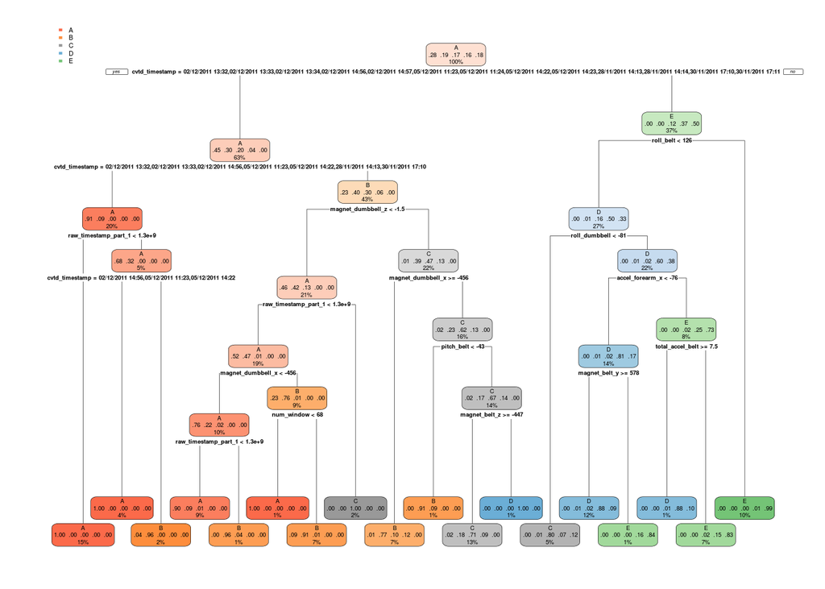

```r
set.seed(34343)
treefit <- rpart(classe ~ ., data=new_training, method="class")
rpart.plot(treefit)
```

## Run the prediction for you decision tree and verify the accuracy with a confusion matrix

```r
tree_predict <- predict(treefit, new_testing, type = "class")
tree_conf <- confusionMatrix(tree_predict, new_testing$classe)
tree_conf
```

```
## Confusion Matrix and Statistics
##
##           Reference
## Prediction    A    B    C    D    E
##          A 2147   65    7    4    0
##          B   60 1265   82   60    0
##          C   25  178 1232  152   49
##          D    0   10   31  945  102
##          E    0    0   16  125 1291
##
## Overall Statistics
##
##                Accuracy : 0.8769
##                  95% CI : (0.8694, 0.8841)
##     No Information Rate : 0.2845
##     P-Value [Acc > NIR] : < 2.2e-16
##
##                   Kappa : 0.8443
##  Mcnemar's Test P-Value : NA
##
## Statistics by Class:
##
##                      Class: A Class: B Class: C Class: D Class: E
## Sensitivity            0.9619   0.8333   0.9006   0.7348   0.8953
## Specificity            0.9865   0.9681   0.9376   0.9782   0.9780
## Pos Pred Value         0.9658   0.8623   0.7531   0.8686   0.9015
## Neg Pred Value         0.9849   0.9603   0.9781   0.9495   0.9765
## Prevalence             0.2845   0.1935   0.1744   0.1639   0.1838
## Detection Rate         0.2736   0.1612   0.1570   0.1204   0.1645
## Detection Prevalence   0.2833   0.1870   0.2085   0.1387   0.1825
## Balanced Accuracy      0.9742   0.9007   0.9191   0.8565   0.9366
```

## Grow and verify the accuracy of a random forest to compare with the single decision tree

```r
set.seed(34343)
rf_fit <- randomForest(classe ~ ., data=new_training)
```

## Run the prediction for your random forest and verify the accuracy with a confusion matrix

```r
rf_predict <- predict(rf_fit, new_testing, type = "class")
rf_conf <- confusionMatrix(rf_predict, new_testing$classe)
rf_conf
```

```
## Confusion Matrix and Statistics
##
##           Reference
## Prediction    A    B    C    D    E
##          A 2232    1    0    0    0
##          B    0 1517    2    0    0
##          C    0    0 1364    3    0
##          D    0    0    2 1283    2
##          E    0    0    0    0 1440
##
## Overall Statistics
##
##                Accuracy : 0.9987
##                  95% CI : (0.9977, 0.9994)
##     No Information Rate : 0.2845
##     P-Value [Acc > NIR] : < 2.2e-16
##
##                   Kappa : 0.9984
##  Mcnemar's Test P-Value : NA
##
## Statistics by Class:
##
##                      Class: A Class: B Class: C Class: D Class: E
## Sensitivity            1.0000   0.9993   0.9971   0.9977   0.9986
## Specificity            0.9998   0.9997   0.9995   0.9994   1.0000
## Pos Pred Value         0.9996   0.9987   0.9978   0.9969   1.0000
## Neg Pred Value         1.0000   0.9998   0.9994   0.9995   0.9997
## Prevalence             0.2845   0.1935   0.1744   0.1639   0.1838
## Detection Rate         0.2845   0.1933   0.1738   0.1635   0.1835
## Detection Prevalence   0.2846   0.1936   0.1742   0.1640   0.1835
## Balanced Accuracy      0.9999   0.9995   0.9983   0.9985   0.9993
```

# Model comparison:

The basic decision tree only yeilded an accuracy of 87.6% while the random forest gave an accuracy of 99.8%. For this reason, we will use the random forest against the testing dataset.

# Final Results

Since the random forest gave us better results, we will use it for our prediction of the testing data

```r
final_predict <- predict(rf_fit, testing, type = "class")
final_predict
```

```
##  1 21  3  4  5  6  7  8  9 10 11 12 13 14 15 16 17 18 19 20
##  B  A  B  A  A  E  D  B  A  A  B  C  B  A  E  E  A  B  B  B
## Levels: A B C D E
```